# Figure2 Individual Species Pres/Abs

```r
load(here("spp_master_ztemp_seus_buoys.RData"))
```

```
cannot open compressed file '/Users/zoekitchel/Documents/grad school/Rutgers/Repositories/Col_Ext/spp_master_ztemp_seus_buoys.RData', probable reason 'No such file or directory'Error in readChar(con, 5L, useBytes = TRUE) : cannot open the connection
```

Highlight particular species:

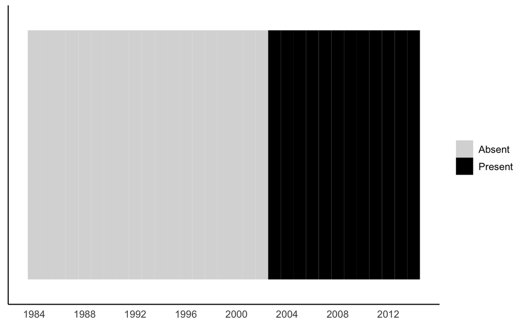

```r
ggplot(spp_master_ztemp_seus_buoy[spp == "Chrysaora melanaster" & reg == "ebs"], aes(x = as.numeric(year), y = spp)) +
  geom_tile(aes(fill = factor(present)), color = "white", size = 0.01) +
  scale_fill_manual(values = c("gray85", "black"), breaks = c(0,1), labels = c("Absent", "Present")) +
  theme_classic() +
  scale_x_continuous(breaks = seq(1984, 2014, by = 4)) +
  theme(legend.title = element_blank(),
        legend.text = element_text(size = 10),
        axis.text.y = element_blank(),
        axis.title.y = element_blank(),
        axis.title.x = element_blank(),
        axis.text.x = element_text(size = 10, angle = 0, vjust = 0.5),
        strip.text.x = element_text(size = 10),
        axis.ticks = element_blank())

ggsave("Chrysaora_melanaster_presabs.eps", width = 6, height = 1, units = "in", path = here("figures","Figure2"))
```

Justification for using species

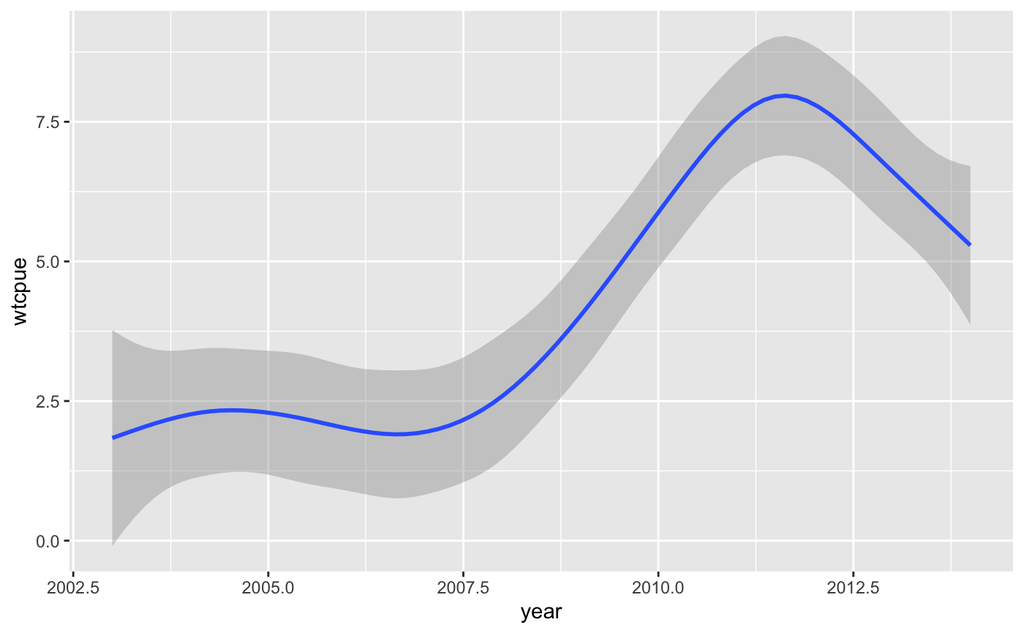

```r
hauls <- data.table(hauls)
dat <- data.table(dat)

hauls.r <- hauls[,.(haulid,region,year)]
chrysaora <- dat[sppocean == "chrysaora melanaster_Pac"]


chrysaora_occurences <- hauls.r[chrysaora, on = "haulid"][region == "AFSC_EBS"]

ggplot(chrysaora_occurences, aes(year, wtcpue)) +
  geom_smooth()
```

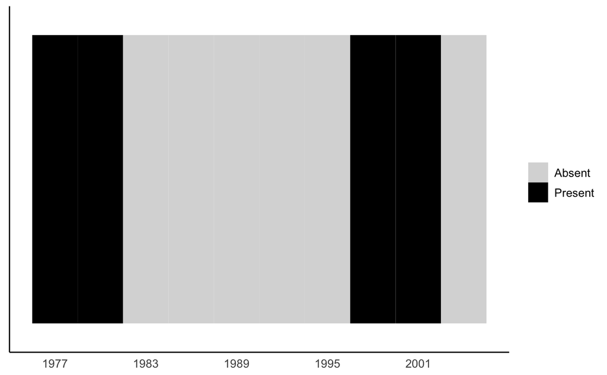

```r
ggplot(spp_master_ztemp_seus_buoy[spp == "Pandalus eous" & reg == "wctri"], aes(x = as.numeric(year), y = spp)) +
  geom_tile(aes(fill = factor(present)), color = "white", size = 0.01) +
  scale_fill_manual(values = c("gray85", "black"), breaks = c(0,1), labels = c("Absent", "Present")) +
  theme_classic() +
  scale_x_continuous(breaks = seq(1977,2004, by = 6)) +
  theme(legend.title = element_blank(),
        legend.text = element_text(size = 10),
        axis.text.y = element_blank(),
        axis.title.y = element_blank(),
        axis.title.x = element_blank(),
        axis.text.x = element_text(size = 10, angle = 0, vjust = 0.5),
        strip.text.x = element_text(size = 10),
        axis.ticks = element_blank())

ggsave("Pandalus_eous_presabs.eps", width = 6, height = 1, units = "in", path = here("figures", "Figure2"))
```

Justification for using species

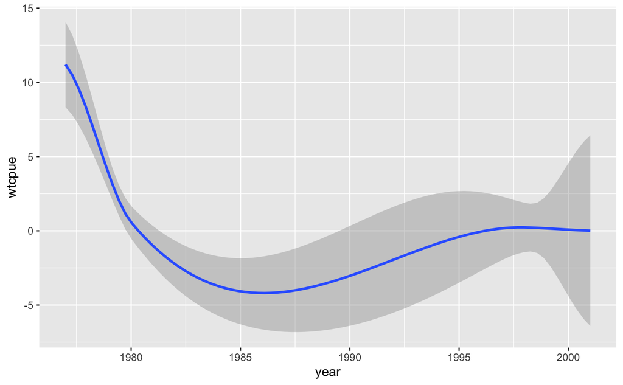

```r
pandalus <- dat[sppocean == "pandalus eous_Pac"]

pandalus_occurences <- hauls.r[pandalus, on = "haulid"][region == "AFSC_WCTri"]

ggplot(pandalus_occurences, aes(year, wtcpue)) +
  geom_smooth()
```

Haemulon aurolineatum

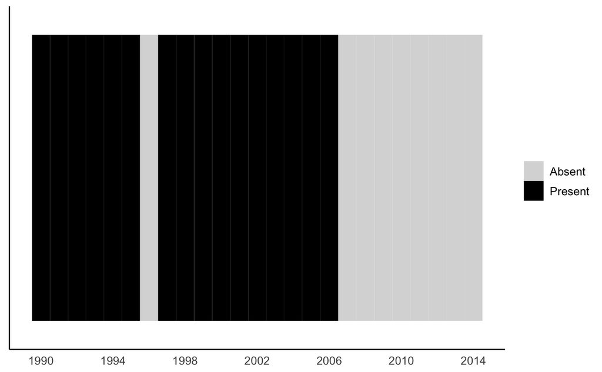

```r
ggplot(spp_master_ztemp_seus_buoy[spp == "Haemulon aurolineatum" & reg == "sa"], aes(x = as.numeric(year), y = spp)) +
  geom_tile(aes(fill = factor(present)), color = "white", size = 0.01) +
  scale_fill_manual(values = c("gray85", "black"), breaks = c(0,1), labels = c("Absent", "Present")) +
  theme_classic() +
  scale_x_continuous(breaks = seq(1990, 2014, by = 4)) +
  theme(legend.title = element_blank(),
        legend.text = element_text(size = 10),
        axis.text.y = element_blank(),
        axis.title.y = element_blank(),
        axis.title.x = element_blank(),
        axis.text.x = element_text(size = 10, angle = 0, vjust = 0.5),
        strip.text.x = element_text(size = 10),
        axis.ticks = element_blank())

ggsave("Haemulon_aurolineatum_presabs.eps", width = 6, height = 1, units = "in", path = here("figures","Figure2"))
```

Justification for species

[figure not shown]

Chionoecetes opilio

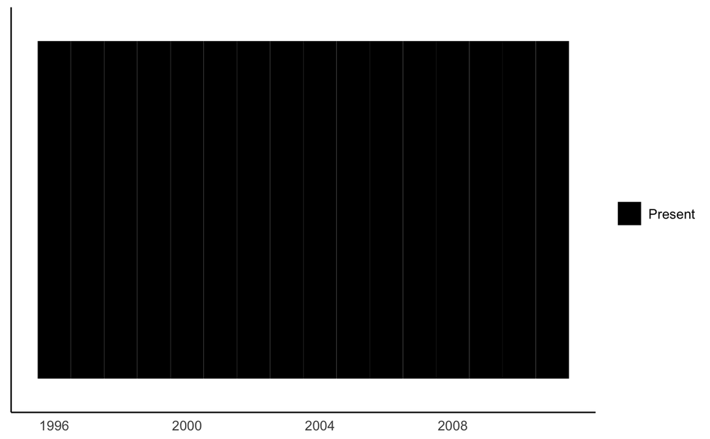

```r
ggplot(spp_master_ztemp_seus_buoy[spp == "Chionoecetes opilio" & reg == "newf"], aes(x = as.numeric(year), y = spp)) +
  geom_tile(aes(fill = factor(present)), color = "white", size = 0.01) +
  scale_fill_manual(values = c("gray85", "black"), breaks = c(0,1), labels = c("Absent", "Present")) +
  theme_classic() +
  scale_x_continuous(breaks = seq(1996, 2011, by = 4)) +
  theme(legend.title = element_blank(),
        legend.text = element_text(size = 10),
        axis.text.y = element_blank(),
        axis.title.y = element_blank(),
        axis.title.x = element_blank(),
        axis.text.x = element_text(size = 10, angle = 0, vjust = 0.5),
        strip.text.x = element_text(size = 10),
        axis.ticks = element_blank())

ggsave("Chionoecetes_opilio_presabs.eps", width = 6, height = 1, units = "in")
```

Chionocetes opilio

Justification for species

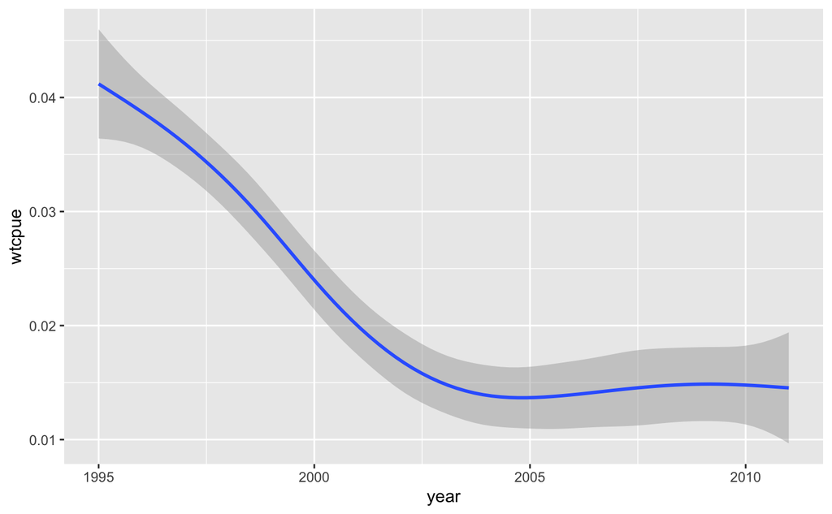

```r
chionocetes <- dat[sppocean == "chionoecetes opilio_Atl"]

chionoecetes_occurences <- hauls.r[chionocetes, on = "haulid"][region == "DFO_Newfoundland"]

ggplot(chionoecetes_occurences, aes(year, wtcpue)) +
  geom_smooth()
```

Highlight: Arrivals:

- AI: Pandalus (cold-water prawn) is a genus of shrimp in the family Pandalidae.
- EBS: Metridium farcimen is a species of sea anemone in the family Metridiidae. It is commonly known as the giant plumose anemone or white-plumed anemone. It is found in the eastern Pacific Ocean from Alaska down to Catalina Island, California.
- GMEX: The Atlantic sea nettle (Chrysaora quinquecirrha), also known as the East Coast sea nettle or US Atlantic sea nettle, is a species of jellyfish that inhabits the Atlantic coast of the United States.
- GOA: Eumicrotremus phrynoides, Toad Lumpsucker
- NEUS: Bathypolypus arcticus is a deep sea octopus that is typically found at depths from 200-600 m in the Atlantic Ocean (Boyle 1987).
- NEWF: Gersemia rubiformis, commonly known as the sea strawberry, is a species of soft coral in the family Nephtheidae.
- SA: The scaled sardine, Harengula jaguana, is a herring-like fish in the family Clupeidae. It is native to coastal waters of the western Atlantic Ocean, from the Gulf of Mexico (where it is known as the pilchard or whitebait) down to Brazil where it is called mata.**good example
- WCTRI: North-Pacific argentine, Argentina sialis (herring)